# Fanning the Flames - Python version

This notebook is intended to be a companion for a corresponding notebook with an R kernel.

### Package management

Much of the power of Python comes from the external libraries and packages. Unfortunately package management is a touchy subject. Currently, for the scientific stack, I recommend using the Anaconda distribution, which is designed to take care of the various versions of packages such that they are consistent and relatively interoperable. However, even so, you will often need to install packages. You can do this using the `conda` program.

The more native means is to use the `pip` program to install packages individually.

Finally, more recently, Windows have begun distributing Python with its OS. You can install directly from the Windows app store (although this is currently in a period of rapid development).

The versions of packages I am currently using for this demonstration are:

```python
import os
import sys
import pandas as pd
import numpy as np
import matplotlib as mpl
import seaborn as sns
import statsmodels as sm
os.getcwd()


print(f"Sytem version: {sys.version}\n")
print(f"Pandas version: {pd.__version__}\n")
print(f"Numpy version: {np.__version__}\n")
print(f"Matplotlib version: {mpl.__version__}\n")

print(f"Seaborn version: {sns.__version__}\n")
print(f"Statsmodels version: {sm.__version__}\n")
```

```
Sytem version: 3.6.7 | packaged by conda-forge | (default, Feb 26 2019, 03:50:56)
[GCC 7.3.0]

Pandas version: 0.24.1

Numpy version: 1.15.4

Matplotlib version: 3.0.3

Seaborn version: 0.9.0

Statsmodels version: 0.9.0
```

Note the use of `import` before first use of that particular package in question.

```python
# Some housekeeping items for better interactivity with IPython
# and Jupyter:

from IPython.core.interactiveshell import InteractiveShell
InteractiveShell.ast_node_interactivity = "all"

pd.set_option('display.width', 80)
pd.set_option('display.max_rows', 10)
pd.set_option('display.max_columns', 10)

%matplotlib inline
```

## 1: Importing data

```python
# Import module for handling database access.
import sqlite3

# Connect to the database
cnx = sqlite3.connect("../data/user_data.sql")
```

```python
# The data are stored as two tables in the db:
users_df = pd.read_sql_query("SELECT * FROM user_accounts", cnx)
```

```python
# Count number of user accounts
pd.read_sql_query('SELECT COUNT(*) FROM user_accounts', cnx)
```

|  | COUNT(*) |
| --- | --- |
| 0 | 11000 |

```python
# What are the account balances for customers over 30?
pd.read_sql_query(
               "SELECT account_balance, user_id FROM user_accounts WHERE age > 30 LIMIT 10", cnx)
```

|  | account_balance | user_id |
| --- | --- | --- |
| 0 | 3.409229 | 3174 |
| 1 | 16.086066 | 6161 |
| 2 | 1.110731 | 6598 |
| 3 | 1.159424 | 8217 |
| 4 | 1.501488 | 9978 |
| 5 | 2.327098 | 6928 |
| 6 | 3.260695 | 9143 |
| 7 | 4.305119 | 8682 |
| 8 | 1.084477 | 9680 |
| 9 | 2.266106 | 4049 |

Yahoo have kindly offered a cross-promotion for our users.

Select the users with a Yahoo email address:

```python
yahoo_users = pd.read_sql_query("SELECT * FROM user_accounts WHERE email LIKE '%yahoo%'", cnx)

yahoo_users[['first_name', 'last_name', 'email']].head()
```

|  | first_name | last_name | email |
| --- | --- | --- | --- |
| 0 | Carlo | Logan | naturalistic2030@yahoo.com |
| 1 | Tiffaney | Rasmussen | alveolarly1829@yahoo.com |
| 2 | Mitchell | George | deidre1830@yahoo.com |
| 3 | Brian | Newton | moralistic2042@yahoo.com |
| 4 | Robbyn | Durham | dhooras1833@yahoo.com |

```python
# It's a good policy to close your db connection early as possible
cnx.close()
```

```python
# The marketing people have the campaign stored in an Excel spreadsheet.
campaign_df = pd.read_excel("../data/advertising_campaign.xlsx")
campaign_df
```

|  | user_id | marketing_level | sales |
| --- | --- | --- | --- |
| 0 | 7661 | 4 | 4.218709 |
| 1 | 5210 | 2 | 2.204847 |
| 2 | 9259 | 6 | 1.820096 |
| 3 | 6121 | 10 | 7.977467 |
| 4 | 4000 | 9 | 2.644286 |
| ... | ... | ... | ... |
| 9995 | 8471 | 2 | 3.367068 |
| 9996 | 6764 | 5 | 4.003581 |
| 9997 | 8784 | 3 | 3.746919 |
| 9998 | 8217 | 7 | 1.190725 |
| 9999 | 9366 | 2 | 3.272120 |

10000 rows × 3 columns

## 2: Exploratory Data Analysis I

We'll first look at the most important information: the users

```python
# Size of the dataset
users_df.shape
```

```
(11000, 12)
```

```python
# Names of columns:
users_df.columns.values
```

```
array(['user_id', 'first_name', 'last_name', 'email', 'password_hashed',
       'gender', 'address', 'age', 'credit_card_num', 'credit_card_exp',
       'security_answer', 'account_balance'], dtype=object)
```

```python
# Quick look at the first few rows:
users_df.head()
```

|  | user_id | first_name | last_name | email | password_hashed | ... | age | credit_card_num | credit_card_exp | security_answer | account_balance |
| --- | --- | --- | --- | --- | --- | --- | --- | --- | --- | --- | --- |
| 0 | 3174 | Mac | Gilbert | athrocyte2057@yandex.com | 31dde7d51fb7ee6b6af7a44b480ea4eda40cdc5924e8d1... | ... | 63 | 4359 4286 7081 7388 | 06/25 | lcd | 3.409229 |
| 1 | 6161 | Jacinto | Holloway | connelly2054@outlook.com | fb2a80887cafe2d0d81689915049478930f66ab07e9fa1... | ... | 62 | 2641 4248 0712 8353 | 08/23 | favorite | 16.086066 |
| 2 | 5976 | Yuko | Shaffer | carnell1945@gmail.com | d23bdf545afcf1d1fbf4ea482c6341944737a6ff4dfc15... | ... | 30 | 4111 6457 8815 1058 | 11/18 | luxury | 1.646357 |
| 3 | 6598 | Carlo | Logan | naturalistic2030@yahoo.com | ca515ffc7c3e2019b0189203b52fd7084c7ddaf80acfdb... | ... | 39 | 3406 509987 49643 | 09/18 | compilation | 1.110731 |
| 4 | 8217 | Sandee | Wolfe | normoblastic1896@outlook.com | 8a314c766a35b29aeeabc0a2bef789f296814ef2d87b78... | ... | 38 | 5464 5693 4366 2146 | 06/21 | alexander | 1.159424 |

5 rows × 12 columns

```python
# Access the age column only:
users_df["age"].head(10)
```

```
0    63
1    62
2    30
3    39
4    38
5    48
6    56
7    34
8    34
9    41
Name: age, dtype: int64
```

```python
# Alternatively:
users_df.loc[0:9, "age"]
```

```
0    63
1    62
2    30
3    39
4    38
5    48
6    56
7    34
8    34
9    41
Name: age, dtype: int64
```

But NEVER:

```python
users_df.age.head(10)
```

```
0    63
1    62
2    30
3    39
4    38
5    48
6    56
7    34
8    34
9    41
Name: age, dtype: int64
```

Just. **Don't.** Even if you see it on StackOverflow.

```python
# Get the data types of each column
users_df.dtypes
```

```
user_id              int64
first_name          object
last_name           object
email               object
password_hashed     object
                    ...
age                  int64
credit_card_num     object
credit_card_exp     object
security_answer     object
account_balance    float64
Length: 12, dtype: object
```

```python
# Get some descriptive statistics for the numerical data:
users_df.describe()
```

|  | user_id | age | account_balance |
| --- | --- | --- | --- |
| count | 11000.000000 | 11000.000000 | 11000.000000 |
| mean | 5000.227364 | 41.076727 | 5.324487 |
| std | 2888.163352 | 14.710706 | 41.227202 |
| min | 0.000000 | 16.000000 | 1.000116 |
| 25% | 2499.750000 | 28.000000 | 1.279275 |
| 50% | 4992.500000 | 41.000000 | 1.813442 |
| 75% | 7504.250000 | 54.000000 | 3.301391 |
| max | 9999.000000 | 66.000000 | 3564.971963 |

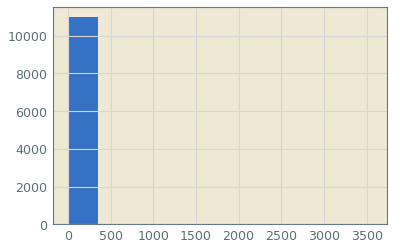

```python
# Univariate description of account balances:
import matplotlib.pyplot as plt
plt.hist(users_df["account_balance"])
```

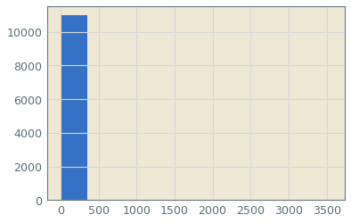

```python
# Alternatively:
users_df["account_balance"].hist()
```

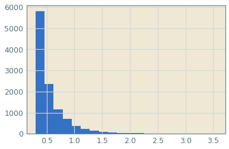

```python
# Brutal! Perhaps, like many resource distributions, this is a Pareto distribution:
# We'll do some feature engineering and create a new column:
users_df["log_account_balance"] = np.log10(users_df["account_balance"] + 1)

users_df["log_account_balance"].hist(bins=20)
```

Nice

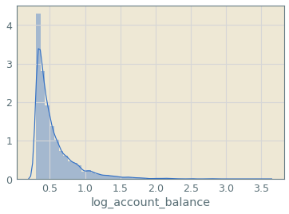

```python
import seaborn as sns
sns.distplot(users_df["log_account_balance"])
```

Even nicer.

```python
# Quantify the missingness:
users_df.isnull().sum().sum()  # 2195
```

```
2195
```

```python
# We don't need the address column:
del users_df["address"]
```

```python
# Alternatively: pop off the queue
# users_df.pop("address")
```

Get the names of the columns

```python
users_df.columns.values
```

```
array(['user_id', 'first_name', 'last_name', 'email', 'password_hashed',
       'gender', 'age', 'credit_card_num', 'credit_card_exp',
       'security_answer', 'account_balance', 'log_account_balance'],
      dtype=object)
```

We could change the default value of missing gender:

```python
users_df["gender"].fillna("Unknown", inplace=True)

users_df["gender"].sample(5)

users_df["gender"].isnull().sum()  #  None
```

```
4951       Male
10178    Female
5714      Other
2939      Other
3828       Male
Name: gender, dtype: object
```

```
0
```

Check for duplicates ('dupes,' as we like to call 'em)

```python
users_df.duplicated().sum()
```

```
1000
```

Drop duplicates

```python
users_df.drop_duplicates(inplace=True)
```

Merge the user data and the corresponding advertising campaign data

```python
data_df = pd.merge(users_df, campaign_df, on="user_id", how="left")
```

*Always* check key properties of your DataFrame after a merge

```python
data_df.shape
data_df.columns.values
data_df.duplicated().sum()
data_df.isnull().sum()
```

```
(10000, 14)
```

```
array(['user_id', 'first_name', 'last_name', 'email', 'password_hashed',
       'gender', 'age', 'credit_card_num', 'credit_card_exp',
       'security_answer', 'account_balance', 'log_account_balance',
       'marketing_level', 'sales'], dtype=object)
```

```
0
```

```
user_id                0
first_name             0
last_name              0
email                  0
password_hashed        0
                      ..
security_answer        0
account_balance        0
log_account_balance    0
marketing_level        0
sales                  0
Length: 14, dtype: int64
```

## 3: Visualization

[output not shown]

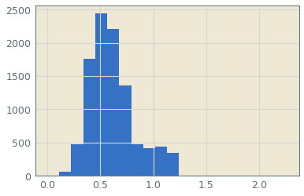

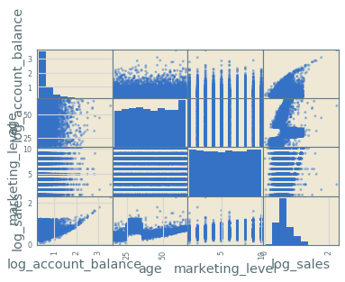

```python
data_df["log_sales"] = np.log10(data_df["sales"] + 1)
data_df["log_sales"].hist(bins=20)

from pandas.plotting import scatter_matrix
scatter_matrix(data_df[["log_account_balance", "age", "marketing_level", "log_sales"]])
```

## 4: Exploratory Data Analysis II and hypothesis testing

Does the marketing level have any effect on sales?

```python
data_df.groupby("marketing_level").mean()["sales"]
```

```
marketing_level
1     2.600379
2     2.915733
3     3.396971
4     3.470250
5     3.674082
6     3.901185
7     3.995114
8     4.289784
9     4.731334
10    4.936115
Name: sales, dtype: float64
```

Looks like its linear!

Upon discussion, marketing finally(!) let us know that their advertising campaign was targeted at customers between the ages of 25 and 35.

**Was this campaign effective?**

```python
# Let's engineer that feature a little more:
data_df["age_demographic"] = np.where([x >= 25 and x <= 35 for x in data_df["age"]], "yes", "no")

# Make it a categorical variable:
data_df["age_demographic"] = data_df["age_demographic"].astype('category')

data_df.dtypes
```

```
user_id                   int64
first_name               object
last_name                object
email                    object
password_hashed          object
                         ...
log_account_balance     float64
marketing_level           int64
sales                   float64
log_sales               float64
age_demographic        category
Length: 16, dtype: object
```

```python
data_df.groupby("age_demographic").mean()["sales"]
```

```
age_demographic
no     2.613189
yes    7.911501
Name: sales, dtype: float64
```

It appears so!

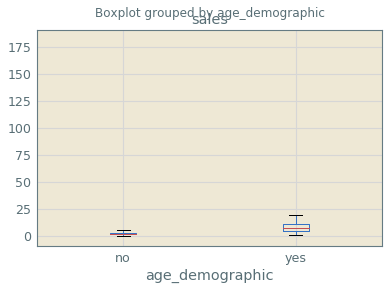

```python
data_df.boxplot("sales", by="age_demographic")
```

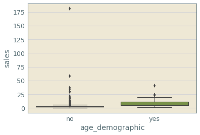

```python
# Alternatively (and nicer handling of outliers):
sns.boxplot(x="age_demographic", y="sales", data=data_df)
```

OK, looks like we're swamped by outliers. Time for the log-transformed version:

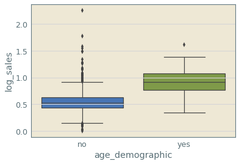

```python
sns.boxplot(x="age_demographic", y="log_sales", data=data_df)
```

Nice.

```python
import statsmodels.api as sm

sm.stats.ttest_ind(data_df.loc[data_df["age_demographic"] == "no", "sales"],
                   data_df.loc[data_df["age_demographic"] == "yes", "sales"])

# t-stat, p-value, df:
```

```
(-77.41724322823191, 0.0, 9998.0)
```

```python
# More compact, but a little more ninja:
sm.stats.ttest_ind(*(x[1] for x in data_df.groupby("age_demographic")["sales"]))
```

```
(-77.41724322823191, 0.0, 9998.0)
```

As expected: highly significant

**Conclusion:** the advertising campaign was very successful! Keep advertising.

Are there more granular ways we can maximize sales?

## 5: Linear Regression

```python
# Take our null model as the mean sales value:
data_df["sales"].mean()
```

```
3.795772486289269
```

```python
import statsmodels.formula.api as smf
mod_null = smf.ols("sales ~ 1", data=data_df).fit()

mod_null.summary()
```

OLS Regression Results

| Dep. Variable: | sales | R-squared: | -0.000 |
| --- | --- | --- | --- |
| Model: | OLS | Adj. R-squared: | -0.000 |
| Method: | Least Squares | F-statistic: | -inf |
| Date: | Wed, 26 Jun 2019 | Prob (F-statistic): | nan |
| Time: | 11:28:08 | Log-Likelihood: | -27009. |
| No. Observations: | 10000 | AIC: | 5.402e+04 |
| Df Residuals: | 9999 | BIC: | 5.403e+04 |
| Df Model: | 0 |  |  |
| Covariance Type: | nonrobust |  |  |

|  | coef | std err | t | P>\|t\| | [0.025 | 0.975] |
| --- | --- | --- | --- | --- | --- | --- |
| Intercept | 3.7958 | 0.036 | 105.325 | 0.000 | 3.725 | 3.866 |

| Omnibus: | 18917.269 | Durbin-Watson: | 2.006 |
| --- | --- | --- | --- |
| Prob(Omnibus): | 0.000 | Jarque-Bera (JB): | 150663349.897 |
| Skew: | 13.825 | Prob(JB): | 0.00 |
| Kurtosis: | 603.689 | Cond. No. | 1.00 |

Warnings:  
[1] Standard Errors assume that the covariance matrix of the errors is correctly specified.

Here's a thought: what if people with higher account balances spent more?

```python
# Single factor: account balance
mod0 = smf.ols("sales ~ account_balance", data=data_df).fit()

mod0.summary()
```

OLS Regression Results

| Dep. Variable: | sales | R-squared: | 0.336 |
| --- | --- | --- | --- |
| Model: | OLS | Adj. R-squared: | 0.336 |
| Method: | Least Squares | F-statistic: | 5051. |
| Date: | Wed, 26 Jun 2019 | Prob (F-statistic): | 0.00 |
| Time: | 11:28:08 | Log-Likelihood: | -24964. |
| No. Observations: | 10000 | AIC: | 4.993e+04 |
| Df Residuals: | 9998 | BIC: | 4.995e+04 |
| Df Model: | 1 |  |  |
| Covariance Type: | nonrobust |  |  |

|  | coef | std err | t | P>\|t\| | [0.025 | 0.975] |
| --- | --- | --- | --- | --- | --- | --- |
| Intercept | 3.5355 | 0.030 | 119.431 | 0.000 | 3.477 | 3.594 |
| account_balance | 0.0499 | 0.001 | 71.072 | 0.000 | 0.048 | 0.051 |

| Omnibus: | 3834.938 | Durbin-Watson: | 1.981 |
| --- | --- | --- | --- |
| Prob(Omnibus): | 0.000 | Jarque-Bera (JB): | 12307.597 |
| Skew: | 2.021 | Prob(JB): | 0.00 |
| Kurtosis: | 6.632 | Cond. No. | 42.5 |

Warnings:  
[1] Standard Errors assume that the covariance matrix of the errors is correctly specified.

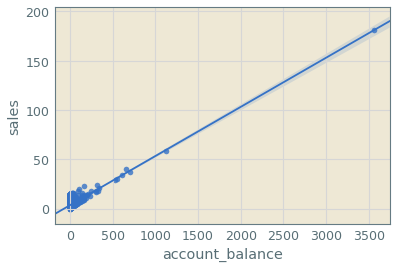

```python
sns.regplot(x="account_balance", y="sales", data=data_df)
```

What do the residual errors look like?

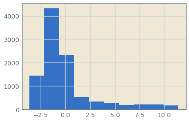

```python
plt.hist(mod0.resid)
```

How does the input from marketing fare in comparison?

```python
# Check the effect of age demographic on sales
modDemographic = smf.ols("sales ~ age_demographic", data=data_df).fit()
modDemographic.summary()
```

OLS Regression Results

| Dep. Variable: | sales | R-squared: | 0.375 |
| --- | --- | --- | --- |
| Model: | OLS | Adj. R-squared: | 0.375 |
| Method: | Least Squares | F-statistic: | 5993. |
| Date: | Wed, 26 Jun 2019 | Prob (F-statistic): | 0.00 |
| Time: | 11:28:10 | Log-Likelihood: | -24661. |
| No. Observations: | 10000 | AIC: | 4.933e+04 |
| Df Residuals: | 9998 | BIC: | 4.934e+04 |
| Df Model: | 1 |  |  |
| Covariance Type: | nonrobust |  |  |

|  | coef | std err | t | P>\|t\| | [0.025 | 0.975] |
| --- | --- | --- | --- | --- | --- | --- |
| Intercept | 2.6132 | 0.032 | 80.821 | 0.000 | 2.550 | 2.677 |
| age_demographic[T.yes] | 5.2983 | 0.068 | 77.417 | 0.000 | 5.164 | 5.432 |

| Omnibus: | 24902.639 | Durbin-Watson: | 2.008 |
| --- | --- | --- | --- |
| Prob(Omnibus): | 0.000 | Jarque-Bera (JB): | 1036939898.253 |
| Skew: | 26.444 | Prob(JB): | 0.00 |
| Kurtosis: | 1579.661 | Cond. No. | 2.54 |

Warnings:  
[1] Standard Errors assume that the covariance matrix of the errors is correctly specified.

What if older players spent more?

```python
# Single factor: age
mod1 = smf.ols("sales ~ age", data=data_df).fit()

mod1.summary()
```

OLS Regression Results

| Dep. Variable: | sales | R-squared: | 0.002 |
| --- | --- | --- | --- |
| Model: | OLS | Adj. R-squared: | 0.002 |
| Method: | Least Squares | F-statistic: | 23.82 |
| Date: | Wed, 26 Jun 2019 | Prob (F-statistic): | 1.07e-06 |
| Time: | 11:28:10 | Log-Likelihood: | -26997. |
| No. Observations: | 10000 | AIC: | 5.400e+04 |
| Df Residuals: | 9998 | BIC: | 5.401e+04 |
| Df Model: | 1 |  |  |
| Covariance Type: | nonrobust |  |  |

|  | coef | std err | t | P>\|t\| | [0.025 | 0.975] |
| --- | --- | --- | --- | --- | --- | --- |
| Intercept | 4.2873 | 0.107 | 40.090 | 0.000 | 4.078 | 4.497 |
| age | -0.0120 | 0.002 | -4.881 | 0.000 | -0.017 | -0.007 |

| Omnibus: | 18938.249 | Durbin-Watson: | 2.006 |
| --- | --- | --- | --- |
| Prob(Omnibus): | 0.000 | Jarque-Bera (JB): | 153515424.160 |
| Skew: | 13.854 | Prob(JB): | 0.00 |
| Kurtosis: | 609.357 | Cond. No. | 130. |

Warnings:  
[1] Standard Errors assume that the covariance matrix of the errors is correctly specified.

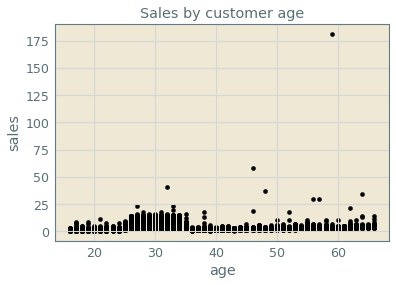

```python
data_df.plot.scatter(x="age", y="sales", color="black")
plt.title("Sales by customer age")
```

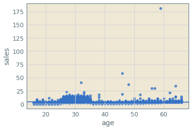

```python
sns.regplot(x="age", y="sales", data=data_df)
```

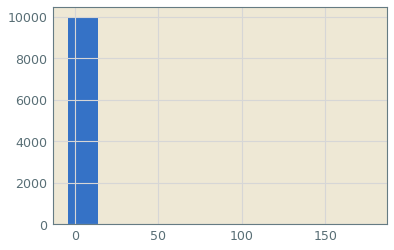

```python
plt.hist(mod1.resid)
```

```python
# Polynomial in age
mod1b = smf.ols("sales ~ age + I(age**2)", data=data_df).fit()

mod1b.summary()
```

OLS Regression Results

| Dep. Variable: | sales | R-squared: | 0.009 |
| --- | --- | --- | --- |
| Model: | OLS | Adj. R-squared: | 0.009 |
| Method: | Least Squares | F-statistic: | 47.18 |
| Date: | Wed, 26 Jun 2019 | Prob (F-statistic): | 4.04e-21 |
| Time: | 11:28:13 | Log-Likelihood: | -26962. |
| No. Observations: | 10000 | AIC: | 5.393e+04 |
| Df Residuals: | 9997 | BIC: | 5.395e+04 |
| Df Model: | 2 |  |  |
| Covariance Type: | nonrobust |  |  |

|  | coef | std err | t | P>\|t\| | [0.025 | 0.975] |
| --- | --- | --- | --- | --- | --- | --- |
| Intercept | 1.9808 | 0.295 | 6.717 | 0.000 | 1.403 | 2.559 |
| age | 0.1165 | 0.016 | 7.511 | 0.000 | 0.086 | 0.147 |
| I(age ** 2) | -0.0016 | 0.000 | -8.389 | 0.000 | -0.002 | -0.001 |

| Omnibus: | 19018.011 | Durbin-Watson: | 2.008 |
| --- | --- | --- | --- |
| Prob(Omnibus): | 0.000 | Jarque-Bera (JB): | 158876717.579 |
| Skew: | 13.980 | Prob(JB): | 0.00 |
| Kurtosis: | 619.865 | Cond. No. | 1.86e+04 |

Warnings:  
[1] Standard Errors assume that the covariance matrix of the errors is correctly specified.  
[2] The condition number is large, 1.86e+04. This might indicate that there are  
strong multicollinearity or other numerical problems.

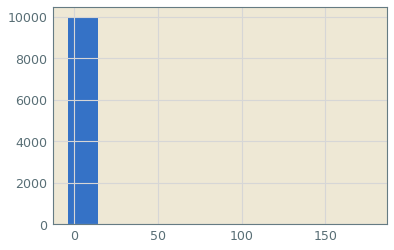

```python
plt.hist(mod1b.resid)
```

Clues for multilinear regression

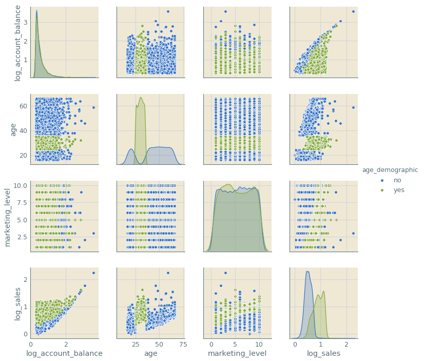

```python
import seaborn as sns

sns.pairplot(
        data_df[["log_account_balance", "age",
                 "marketing_level", "log_sales", "age_demographic"]],
        hue='age_demographic')
```

Nice.

```python
mod2 = smf.ols(
    "sales ~ age + I(age**2) + age_demographic + marketing_level + account_balance",
    data=data_df).fit()

mod2.summary()
```

OLS Regression Results

| Dep. Variable: | sales | R-squared: | 0.805 |
| --- | --- | --- | --- |
| Model: | OLS | Adj. R-squared: | 0.804 |
| Method: | Least Squares | F-statistic: | 8226. |
| Date: | Wed, 26 Jun 2019 | Prob (F-statistic): | 0.00 |
| Time: | 11:28:20 | Log-Likelihood: | -18848. |
| No. Observations: | 10000 | AIC: | 3.771e+04 |
| Df Residuals: | 9994 | BIC: | 3.775e+04 |
| Df Model: | 5 |  |  |
| Covariance Type: | nonrobust |  |  |

|  | coef | std err | t | P>\|t\| | [0.025 | 0.975] |
| --- | --- | --- | --- | --- | --- | --- |
| Intercept | 0.6263 | 0.134 | 4.666 | 0.000 | 0.363 | 0.889 |
| age_demographic[T.yes] | 6.3040 | 0.043 | 146.031 | 0.000 | 6.219 | 6.389 |
| age | -0.0667 | 0.007 | -9.533 | 0.000 | -0.080 | -0.053 |
| I(age ** 2) | 0.0015 | 8.53e-05 | 17.590 | 0.000 | 0.001 | 0.002 |
| marketing_level | 0.2515 | 0.006 | 45.606 | 0.000 | 0.241 | 0.262 |
| account_balance | 0.0501 | 0.000 | 131.590 | 0.000 | 0.049 | 0.051 |

| Omnibus: | 810.427 | Durbin-Watson: | 1.992 |
| --- | --- | --- | --- |
| Prob(Omnibus): | 0.000 | Jarque-Bera (JB): | 2417.953 |
| Skew: | 0.427 | Prob(JB): | 0.00 |
| Kurtosis: | 5.252 | Cond. No. | 1.91e+04 |

Warnings:  
[1] Standard Errors assume that the covariance matrix of the errors is correctly specified.  
[2] The condition number is large, 1.91e+04. This might indicate that there are  
strong multicollinearity or other numerical problems.

```python
mod3 = smf.ols(
    "sales ~ age + I(age**2) + marketing_level:age_demographic + account_balance",
    data=data_df).fit()

mod3.summary()
```

OLS Regression Results

| Dep. Variable: | sales | R-squared: | 0.948 |
| --- | --- | --- | --- |
| Model: | OLS | Adj. R-squared: | 0.948 |
| Method: | Least Squares | F-statistic: | 3.678e+04 |
| Date: | Wed, 26 Jun 2019 | Prob (F-statistic): | 0.00 |
| Time: | 11:28:21 | Log-Likelihood: | -12183. |
| No. Observations: | 10000 | AIC: | 2.438e+04 |
| Df Residuals: | 9994 | BIC: | 2.442e+04 |
| Df Model: | 5 |  |  |
| Covariance Type: | nonrobust |  |  |

|  | coef | std err | t | P>\|t\| | [0.025 | 0.975] |
| --- | --- | --- | --- | --- | --- | --- |
| Intercept | 2.0320 | 0.069 | 29.405 | 0.000 | 1.897 | 2.167 |
| age | -0.0670 | 0.004 | -18.726 | 0.000 | -0.074 | -0.060 |
| I(age ** 2) | 0.0015 | 4.35e-05 | 34.721 | 0.000 | 0.001 | 0.002 |
| marketing_level:age_demographic[no] | -0.0031 | 0.003 | -1.072 | 0.284 | -0.009 | 0.003 |
| marketing_level:age_demographic[yes] | 1.1418 | 0.004 | 291.920 | 0.000 | 1.134 | 1.150 |
| account_balance | 0.0500 | 0.000 | 255.766 | 0.000 | 0.050 | 0.050 |

| Omnibus: | 6282.187 | Durbin-Watson: | 1.971 |
| --- | --- | --- | --- |
| Prob(Omnibus): | 0.000 | Jarque-Bera (JB): | 92260.475 |
| Skew: | -2.796 | Prob(JB): | 0.00 |
| Kurtosis: | 16.789 | Cond. No. | 1.91e+04 |

Warnings:  
[1] Standard Errors assume that the covariance matrix of the errors is correctly specified.  
[2] The condition number is large, 1.91e+04. This might indicate that there are  
strong multicollinearity or other numerical problems.

### Prediction

Create a DataFrame that spans the range of our desired parameters:

Let's see what happens if we turn our marketing **UP TO ELEVEN!!!!**

```python
pred_df = pd.DataFrame({"age": list(np.arange(16, 65, 5))*2*100*11,
                        "age_demographic": ["yes","no"]*10*100*11,
                        "account_balance": list(np.arange(0, 1000, 10))*10*2*11,
                        "marketing_level": list(np.arange(1, 12))*10*2*100} )
```

```python
# Generate the predicted sales according to the model :
pred_df['pred_sale_amount'] = mod3.predict(pred_df)
```

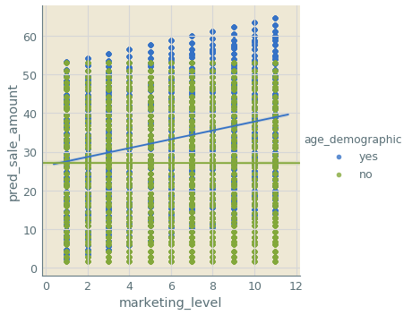

```python
# Plot the model
sns.lmplot("marketing_level", 'pred_sale_amount', data=pred_df, hue="age_demographic")
```

**YES!**

So there is definitely an interaction effect between marketing level and the target demographic. What if we left out the account balance? Or left out the linear age term?

```python
mod4 = smf.ols("sales ~ age + I(age**2) + marketing_level:age_demographic", data=data_df).fit()

mod5 = smf.ols("sales ~ I(age**2) + marketing_level:age_demographic", data=data_df).fit()
```

What are the AIC scores for each of these models?

```python
print(*[f"AIC for model {n}: {x.aic}\n" for n, x in enumerate([mod0, mod1, mod2, mod3, mod4, mod5])])
```

```
AIC for model 0: 49932.38421984795
 AIC for model 1: 53998.032001277854
 AIC for model 2: 37707.50498856515
 AIC for model 3: 24377.55339611073
 AIC for model 4: 44585.14647833382
 AIC for model 5: 44632.83750403216
```

Model 3 is the bestus!

In other words: sales are a function of account balance, age (with a weak square term), plus a strong interaction between marketing level and target demographic (age between 25 ande 35).

**BOTTOM LINE:** There is no observable market saturation for the target demographic. Perhaps further increase sales by targeting older players, and those with higher account balances. Maybe a 'premier tier' account level?

Stepwise AIC: look in scikit-learn.

Until next time...

The end...